# Factorial ANOVA

## factorial ANOVA

- Between subjects (vs within) is where everyone is assigned to 1 group
- 2-way = 2 IVs, 3-way = 3 IVs, etc
- Advantages include: 1) efficiency 2) generalizability 3) interactions

## factorial ANOVA

|  |  | Factor | A | Marginal Means |
| --- | --- | --- | --- | --- |
|  |  | Tx | Control |  |
| B | neutral | 7.6 | 5.0 | 6.33 |
|  | sad | 8.3 | 5.0 | 6.66 |
|  | happy | 7.3 | 8.0 | 7.66 |
| ______ | _______ | ______ | ____________ | ______________________ |
| M.M |  | 7.77 | 6.0 | 6.88 |

## SS decomposition

- SStotal = SSbetween + SSwithin
- SSbetween into three (or more) components (A,B,AxB)

## Marginal vs cell means

|  |  | Factor | A | Marginal Means |
| --- | --- | --- | --- | --- |
|  |  | Tx | Control |  |
| B | neutral | 7.6 | 5.0 | 6.33 |
|  | sad | 8.3 | 5.0 | 6.66 |
|  | happy | 7.3 | 8.0 | 7.66 |
| ______ | _______ | ______ | ____________ | ______________________ |
| M.M |  | 7.77 | 6.0 | 6.88 |

- marginal for main effects
- cell means for interaction

## what do interactions with nominal data look like?

- and can I “see” main effects too?

## equation

- similar to effect coding within regression

\[ Y_{ijk} = \mu + \alpha_{j} + \beta_{k} + \alpha \beta_{jk}+\varepsilon_{ijk} \]

\[ \alpha_{j} = \mu_{j} - \mu \]

```r
library(tidyverse)
tribble(
  ~x, ~y,  ~z,
  "a", 2,  3.6,
  "b", 1,  8.5
)
```

```
## # A tibble: 2 x 3
##   x         y     z
##   <chr> <dbl> <dbl>
## 1 a        2.  3.60
## 2 b        1.  8.50
```

## interactions

- main effects are on the marginal means
- interactions are about the cell means
- what is not expected based on the main effects (marginal means)
- similar to contingency table tests of independence from last semester

## Interpretting interactions part 1

- An interaction is present when the simple effects (akin to simple main effect - more below) of one independent variable are not the same at all levels of the second independent variable.
- If there in an interaction, main effects are hard to interpret, much more so than with continuous interactions

## how is this similar to a linear model?

- is this: \[ Y_{ijk} = \mu + \alpha_{j} + \beta_{k} + \alpha \beta_{jk}+\varepsilon_{ijk} \]
- this? \[ Y_{ijk} = b_{0} + b_{1}J + b_{2}K + b_{3}JK + \varepsilon_{ijk} \]

## Effect coding a factorial ANOVA

- j-1 and k-1 variables for main effects
- (j-1)(k-1) variables for interaction  
  \(J_{ij}\) = 1 if in column j, -1 if in last column, 0 for all other columns  
  \(K_{ik}\) = 1 if in row k, -1 if in last row, 0 for all other rows  
  \(JK_{i}\) = pairwise product of each J with K variable

## linear model equation

\[ Y_{ijk} = b_{0} + b_{1}J1 + b_{2}K1 + b_{3}K2 + b_{4}J1K1 + b_{5}J1K2 +\varepsilon_{ijk} \]

|  |  | Factor | A | Marginal Means |
| --- | --- | --- | --- | --- |
|  |  | Tx | Control |  |
| B | neutral | 7.6 | 5.0 | 6.33 |
|  | sad | 8.3 | 5.0 | 6.66 |
|  | happy | 7.3 | 8.0 | 7.66 |
| ______ | _______ | ______ | ____________ | ______________________ |
| M.M |  | 7.77 | 6.0 | 6.88 |

## coding

| row | column | J1 | K1 | K2 | J1K1 | J1K2 |
| --- | --- | --- | --- | --- | --- | --- |
| 1 | 1 | 1 | 1 | 0 | 1 | 0 |
| 1 | 2 | -1 | 1 | 0 | -1 | 0 |
| 2 | 1 | 1 | 0 | 1 | 0 | 1 |
| 2 | 2 | -1 | 0 | 1 | 0 | -1 |
| 3 | 1 | 1 | -1 | -1 | -1 | -1 |
| 3 | 2 | -1 | -1 | -1 | 1 | 1 |

## but where is this in our output if ANOVA is regression?

## example

```r
data
```

```
##      id  Anxiety   Stress   group SupportLevel
## 1     2 10.18520  3.19813      Tx          med
## 2     4  5.58873  7.00840 Control          med
## 3     6  6.58500  6.17400      Tx         high
## 4    19  8.95430  8.69884      Tx         high
## 5    40  7.59910  5.26707 Control          med
## 6    45  8.15600  5.12485      Tx          med
## 7    51  9.08020  6.85380      Tx          med
## 8    54  3.41339  1.77080 Control          low
## 9    86  8.65810  3.75282      Tx          med
## 10   92  4.84619  5.44990      Tx         high
## 11  103  5.74215  5.62860      Tx         high
## 12  109  6.30689  0.87730 Control          low
## 13  128 10.62630  6.73299      Tx          med
## 14  129  6.74786  4.43970 Control          med
```

[output cut: 104 more lines]

```r
data %>%
  select(group, SupportLevel) %>%
  table()
```

```
##          SupportLevel
## group     low med high
##   Control   9  37   10
##   Tx        3  30   29
```

## aov function

```r
aov.1 <- aov(Anxiety ~ group + SupportLevel + group*SupportLevel, data=data)
summary(aov.1)
```

```
##                     Df Sum Sq Mean Sq F value   Pr(>F)
## group                1    5.4    5.37   1.051    0.307
## SupportLevel         2  137.7   68.86  13.484 5.66e-06 ***
## group:SupportLevel   2    8.7    4.35   0.851    0.430
## Residuals          112  572.0    5.11
## ---
## Signif. codes:  0 '***' 0.001 '**' 0.01 '*' 0.05 '.' 0.1 ' ' 1
```

## lm anova

```r
lm.1 <- lm(Anxiety ~ group + SupportLevel + group*SupportLevel, data=data)
anova(lm.1)
```

```
## Analysis of Variance Table
##
## Response: Anxiety
##                     Df Sum Sq Mean Sq F value    Pr(>F)
## group                1   5.37   5.369  1.0514    0.3074
## SupportLevel         2 137.72  68.861 13.4838 5.663e-06 ***
## group:SupportLevel   2   8.69   4.347  0.8512    0.4296
## Residuals          112 571.98   5.107
## ---
## Signif. codes:  0 '***' 0.001 '**' 0.01 '*' 0.05 '.' 0.1 ' ' 1
```

## lm summary with nominal variables

```
##                       term   estimate std.error statistic      p.value
## 1              (Intercept)  9.1246900 0.7532869 12.113166 4.300971e-22
## 2                  groupTx -1.5105433 1.5065739 -1.002635 3.181984e-01
## 3          SupportLevelmed -0.9782492 0.8399211 -1.164692 2.466186e-01
## 4         SupportLevelhigh -3.5815670 1.0383344 -3.449339 7.930209e-04
## 5  groupTx:SupportLevelmed  1.8754245 1.6056224  1.168036 2.452727e-01
## 6 groupTx:SupportLevelhigh  2.2204286 1.7194663  1.291348 1.992420e-01
```

\[ Y_{ijk} = b_{0} + b_{1}J1 + b_{2}K1 + b_{3}K2 + b_{4}J1K1 + b_{5}J1K2 +\varepsilon_{ijk} \]

## But what contrasts did R use?

```r
contrasts(data$group)
```

```
##         Tx
## Control  0
## Tx       1
```

```r
contrasts(data$SupportLevel)
```

```
##      med high
## low    0    0
## med    1    0
## high   0    1
```

- we will see why this doesn’t matter soon

## Interpretting interactions

- beyond noticing whether cell means look different we can do formal tests
- ~3 types

## Interpretting interactions part 2

’1. Is the interaction significant? If not, this helps interpret our main effects. If it is, we can graph and interpret or also do additional tets.

```r
aov.1 <- aov(Anxiety ~ group + SupportLevel + group*SupportLevel, data=data)
aov.0 <- aov(Anxiety ~ group + SupportLevel, data=data)

anova(aov.0, aov.1)
```

```
## Analysis of Variance Table
##
## Model 1: Anxiety ~ group + SupportLevel
## Model 2: Anxiety ~ group + SupportLevel + group * SupportLevel
##   Res.Df    RSS Df Sum of Sq      F Pr(>F)
## 1    114 580.68
## 2    112 571.98  2    8.6946 0.8512 0.4296
```

## Interpretting interactions part 2

’2. regression coefficients

\[ Y_{ijk} = b_{0} + b_{1}J1 + b_{2}K1 + b_{3}K2 + b_{4}J1K1 + b_{5}J1K2 +\varepsilon_{ijk} \] - Remember, this is likely done with default dummy - Typically not used as you are likely interested in more than just a few comparisons

## Interpretting interactions part 2

’3. Planned contrasts/Post hoc comparisons/simple main effects

- All of these fall under the rubric of ‘contrasts’
- The most basic o these is Tukey honestly significant difference

```r
TukeyHSD(aov.1)
```

```
##   Tukey multiple comparisons of means
##     95% family-wise confidence level
##
## Fit: aov(formula = Anxiety ~ group + SupportLevel + group * SupportLevel, data = data)
##
## $group
##                 diff       lwr       upr     p adj
## Tx-Control -0.427179 -1.252644 0.3982863 0.3074021
##
## $SupportLevel
##                diff       lwr        upr     p adj
## med-low  -0.3527543 -2.035355  1.3298467 0.8724259
## high-low -2.4652166 -4.237192 -0.6932408 0.0036321
## high-med -2.1124623 -3.193595 -1.0313300 0.0000281
##
## $`group:SupportLevel`
##                                diff       lwr        upr     p adj
## Tx:low-Control:low       -1.5105433 -5.879098  2.8580117 0.9161763
## Control:med-Control:low  -0.9782492 -3.413737  1.4572381 0.8525525
## Tx:med-Control:low       -0.6133680 -3.103828  1.8770916 0.9798772
## Control:high-Control:low -3.5815670 -6.592386 -0.5707482 0.0100559
## Tx:high-Control:low      -2.8716817 -5.372031 -0.3713328 0.0145676
## Control:med-Tx:low        0.5322941 -3.401373  4.4659610 0.9987682
## Tx:med-Tx:low             0.8971753 -3.070762  4.8651125 0.9862766
## Control:high-Tx:low      -2.0710237 -6.384626  2.2425788 0.7316435
## Tx:high-Tx:low           -1.3611384 -5.335290  2.6130133 0.9192628
## Tx:med-Control:med        0.3648812 -1.245041  1.9748037 0.9861282
## Control:high-Control:med -2.6033178 -4.938803 -0.2678325 0.0195879
## Tx:high-Control:med      -1.8934325 -3.518611 -0.2682536 0.0125644
## Control:high-Tx:med      -2.9681990 -5.360955 -0.5754428 0.0062447
## Tx:high-Tx:med           -2.2583137 -3.964771 -0.5518563 0.0027702
## Tx:high-Control:high      0.7098853 -1.693162  3.1129329 0.9558328
```

## post hoc tests

- Mainly adjust error rates for multiple comparisons
- Planned contrasts, a priori: Holm, Dunn-Bonnferoni, perhaps Tukey
- All pairwise comparisons (maybe a priori): Tukey
- Post hoc fishing: Scheffe, perhaps Tukey if you can sleep at night

```r
# library(lsmeans) outdated, but code still works
library(emmeans) ## new and shiny
em.1<- emmeans(aov.1, c("group", "SupportLevel"))
# can be used to test numerous a prior and post hoc hypotheses
# estimated means especially important for graphing
# see more here:
#https://cran.r-project.org/web/packages/emmeans/vignettes/basics.html
```

## Quick plot

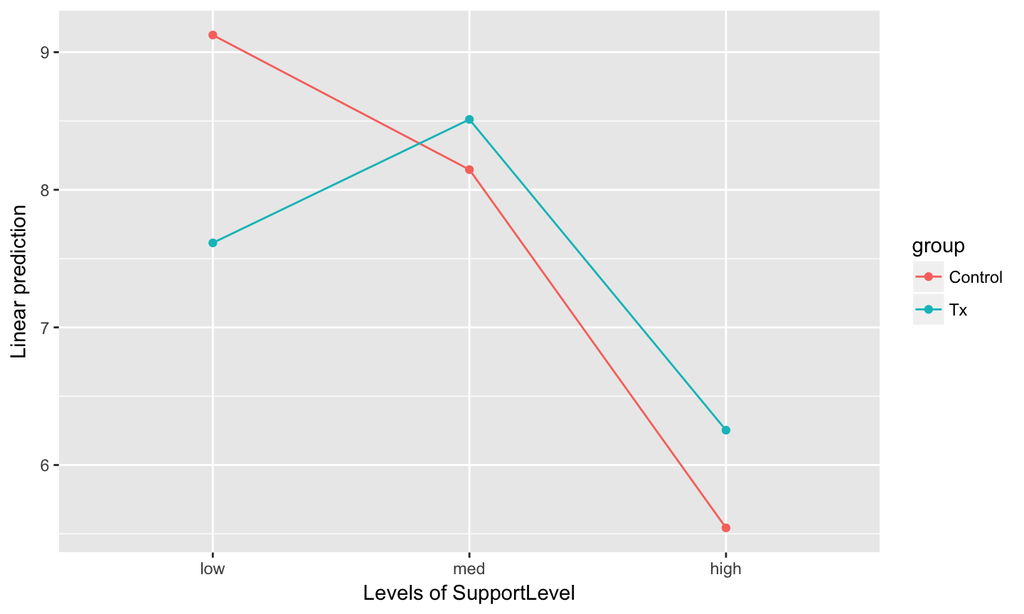

```r
emmip(aov.1, group ~ SupportLevel)
```

```r
em.1
```

```
##  group   SupportLevel   emmean        SE  df lower.CL  upper.CL
##  Control low          9.124690 0.7532869 112 7.632149 10.617231
##  Tx      low          7.614147 1.3047312 112 5.028989 10.199304
##  Control med          8.146441 0.3715188 112 7.410324  8.882558
##  Tx      med          8.511322 0.4125922 112 7.693823  9.328821
##  Control high         5.543123 0.7146307 112 4.127174  6.959072
##  Tx      high         6.253008 0.4196456 112 5.421534  7.084482
##
## Confidence level used: 0.95
```

```r
emmeans(em.1, specs = "group")
```

```
## NOTE: Results may be misleading due to involvement in interactions
```

```
##  group     emmean        SE  df lower.CL upper.CL
##  Control 7.604751 0.3675995 112 6.876400 8.333103
##  Tx      7.459492 0.4771045 112 6.514171 8.404814
##
## Results are averaged over the levels of: SupportLevel
## Confidence level used: 0.95
```

```r
emmeans(aov.1, pairwise ~ group)
```

```
## NOTE: Results may be misleading due to involvement in interactions
```

```
## $emmeans
##  group     emmean        SE  df lower.CL upper.CL
##  Control 7.604751 0.3675995 112 6.876400 8.333103
##  Tx      7.459492 0.4771045 112 6.514171 8.404814
##
## Results are averaged over the levels of: SupportLevel
## Confidence level used: 0.95
##
## $contrasts
##  contrast     estimate       SE  df t.ratio p.value
##  Control - Tx 0.145259 0.602294 112   0.241  0.8099
##
## Results are averaged over the levels of: SupportLevel
```

## emmeans can also do tukey (and other adjustments)

```r
pairs(em.1, adjust = "tukey")
```

```
##  contrast                     estimate        SE  df t.ratio p.value
##  Control,low - Tx,low        1.5105433 1.5065739 112   1.003  0.9162
##  Control,low - Control,med   0.9782492 0.8399211 112   1.165  0.8526
##  Control,low - Tx,med        0.6133680 0.8588792 112   0.714  0.9799
##  Control,low - Control,high  3.5815670 1.0383344 112   3.449  0.0101
##  Control,low - Tx,high       2.8716817 0.8622898 112   3.330  0.0146
##  Tx,low - Control,med       -0.5322941 1.3565949 112  -0.392  0.9988
##  Tx,low - Tx,med            -0.8971753 1.3684137 112  -0.656  0.9863
##  Tx,low - Control,high       2.0710237 1.4876225 112   1.392  0.7316
##  Tx,low - Tx,high            1.3611384 1.3705568 112   0.993  0.9193
##  Control,med - Tx,med       -0.3648812 0.5552104 112  -0.657  0.9861
##  Control,med - Control,high  2.6033178 0.8054336 112   3.232  0.0196
##  Control,med - Tx,high       1.8934325 0.5604718 112   3.378  0.0126
##  Tx,med - Control,high       2.9681990 0.8251845 112   3.597  0.0062
##  Tx,med - Tx,high            2.2583137 0.5885022 112   3.837  0.0028
##  Control,high - Tx,high     -0.7098853 0.8287337 112  -0.857  0.9558
##
## P value adjustment: tukey method for comparing a family of 6 estimates
```

```r
# try "holm" and "bon"
```

## post hoc tests

```r
# equivalent to pairs function above
#contrast(em.1, method = "pairwise")
contrast(em.1, method = "eff")
```

```
##  contrast               estimate        SE  df t.ratio p.value
##  Control,low effect   1.59256821 0.6848238 112   2.326  0.0437
##  Tx,low effect        0.08202487 1.1070555 112   0.074  0.9411
##  Control,med effect   0.61431902 0.4274424 112   1.437  0.1841
##  Tx,med effect        0.97920021 0.4518603 112   2.167  0.0485
##  Control,high effect -1.98899879 0.6566234 112  -3.029  0.0179
##  Tx,high effect      -1.27911352 0.4561701 112  -2.804  0.0179
##
## P value adjustment: fdr method for 6 tests
```

## simple main effects

```r
joint_tests(aov.1, by = "SupportLevel")
```

```
## SupportLevel = low:
##  model term df1 df2 F.ratio p.value
##  group        1 112   1.005  0.3182
##
## SupportLevel = med:
##  model term df1 df2 F.ratio p.value
##  group        1 112   0.432  0.5124
##
## SupportLevel = high:
##  model term df1 df2 F.ratio p.value
##  group        1 112   0.734  0.3935
```

## more post hoc tests

```r
#library(multcomp)
# multcomp::glht(aov.1)

# Nice package that allows you to do many of the same functions as
# lsmeans but it has one major downside: MASS is loaded and
# thus masks dplyr::select
```

```r
library(phia)
testInteractions(aov.1, pairwise="SupportLevel")
```

```
## F Test:
## P-value adjustment method: holm
##             Value  Df Sum of Sq       F    Pr(>F)
##  low-med  0.04054   1      0.01  0.0025  0.959819
## low-high  2.47135   1     42.20  8.2631  0.009686 **
## med-high  2.43082   1    121.31 23.7528 1.091e-05 ***
## Residuals         112    571.98
## ---
## Signif. codes:  0 '***' 0.001 '**' 0.01 '*' 0.05 '.' 0.1 ' ' 1
```

```r
testInteractions(aov.1, pairwise="group")
```

```
## F Test:
## P-value adjustment method: holm
##              Value  Df Sum of Sq      F Pr(>F)
## Control-Tx 0.14526   1      0.30 0.0582 0.8099
## Residuals          112    571.98
```

## different types of Sums of Squares

- 3 types, 3 different hypotheses testing strategies
- Type 1, hierarchical (what R does)
- Type 3, simultaneous
- Type 2, looks at higher- versus lower-order
- SSwithin and SSinteraction will be same, regardless
- All about how we want to interpret main effects (which we often don’t)

## Type 1: Hierarchical (what R does)

- Think of it as model comparisons  
  A: anova(null, Factor A)  
  B: anova(Factor A, FactorA+B)  
  AB: anova(FactorA+B, FactorA+B+A*B)
- SS is just like our partial correlation calculation for R2 when adding terms to hierarchical regression

## Type 3: Controls for all predictors

A: anova(Factor B+A*B, FactorA+B+A*B)  
B: anova(Factor A+A*B, FactorA+B+A*B)  
AB: anova(FactorA+B, FactorA+B+A*B)

- Most common, most recommended
- Still strange, in that it tests higher order term without a lower order term in the model
- Use Anova function from car package

## Type 2: Not popular

A: anova(Factor B, FactorA+B)  
B: anova(Factor A, FactorA+B)  
AB: anova(FactorA+B, FactorA+B+A*B)

- Need to use car::Anova function
- Most interpretable, in my opinion.

## Effect sizes

- Eta squared is like R squared for an effect SS effect / SS total
- Partial eta squared (SS effect / (SS effect + SS resid))
- the variance explained by a given variable of the variance remaining explained by other predictors
- Partial will always be larger, but not interpretable with sig interaction

```r
library(lsr)
etaSquared(aov.1)
```

```
##                         eta.sq eta.sq.part
## group              0.003305332 0.004165048
## SupportLevel       0.190285765 0.194056573
## group:SupportLevel 0.012012944 0.014973213
```

## Don’t forget omega squared and cohen’s f

- Better than eta, adjusts for bias
- Omega Squared is always smaller than Eta Squared.
- see: http://daniellakens.blogspot.com/2015/06/why-you-should-use-omega-squared.html
- cohen’s f is used in pwr

## ANCOVA

- ANalysis of COVAriance
- aka regression with continuous and nominal variables
- given a special name because of historical reasons
- Typically, when someone says they are doing an ANCOVA they are focused on comparing group means adjusted for some covariate

## ANCOVA

\[ \hat{Y} = b_{0} + b_{1}D_{1} + b_{2}D_{2} + b_{3}GPA \] - how do you interpret each term? - what does this look like graphed? - Would b1 and b2 change if we ran a model without GPA?

## 2 advantages of ANCOVA

1. Greater power
2. Adjustment of/controlling for covariate

## ANCOVA power advantages

- what is SS residual?
- how is it used to test your model?
- how can you decrease SS residual?

## ANCOVA power advantages

- power does not necessarily incrase if covariate is related to the predictor (e.g., group). Why?
- how do you find groups not related to the covariate?

## Controlling for background covariates

- in experimental designs, power should be main focus
- in quasi-experimental designs, covariates should help “equate” groups

\[ \hat{Y} = b_{0} + b_{1}D_{1} + b_{2}D_{2} + b_{3}GPA \]

- note: you are now making a different prediction for each individual, rather than having the same prediction for all group members
- likely also reduces SS residual

## Controlling for background covariates

- controlling for is not a panacea
- does not fix issues when random assigment is ineffective
- could create greater group difference, no difference or even reverse the difference

## Standard ANCOVA assumes no interactions; regression association is the same across groups

\[ \hat{Y} = b_{0} + b_{1}D_{1} + b_{2}D_{2} + b_{3}GPA \]

\[ \hat{Y} = b_{0} + b_{1}D_{1} + b_{2}D_{2} + b_{3}GPA + b_{4}(D_{1} * GPA) + b_{5}(D_{2} * GPA) \]

```r
aov.2 <- aov(Anxiety ~ group + SupportLevel + group*SupportLevel + Stress, data=data)
summary(aov.2)
```

```
##                     Df Sum Sq Mean Sq F value   Pr(>F)
## group                1    5.4    5.37   1.063   0.3048
## SupportLevel         2  137.7   68.86  13.630 5.09e-06 ***
## Stress               1   14.0   14.00   2.771   0.0988 .
## group:SupportLevel   2    5.9    2.93   0.580   0.5614
## Residuals          111  560.8    5.05
## ---
## Signif. codes:  0 '***' 0.001 '**' 0.01 '*' 0.05 '.' 0.1 ' ' 1
```

```r
summary(aov.1)
```

```
##                     Df Sum Sq Mean Sq F value   Pr(>F)
## group                1    5.4    5.37   1.051    0.307
## SupportLevel         2  137.7   68.86  13.484 5.66e-06 ***
## group:SupportLevel   2    8.7    4.35   0.851    0.430
## Residuals          112  572.0    5.11
## ---
## Signif. codes:  0 '***' 0.001 '**' 0.01 '*' 0.05 '.' 0.1 ' ' 1
```

```r
em.2<- emmeans(aov.2, c("group", "SupportLevel"))
em.2
```

```
##  group   SupportLevel   emmean        SE  df lower.CL  upper.CL
##  Control low          9.395306 0.7710288 111 7.867461 10.923151
##  Tx      low          8.132124 1.3436644 111 5.469563 10.794685
##  Control med          8.196489 0.3710552 111 7.461218  8.931759
##  Tx      med          8.555469 0.4114513 111 7.740151  9.370788
##  Control high         5.480706 0.7120352 111 4.069761  6.891651
##  Tx      high         6.027439 0.4441021 111 5.147421  6.907457
##
## Confidence level used: 0.95
```

```r
em.1
```

```
##  group   SupportLevel   emmean        SE  df lower.CL  upper.CL
##  Control low          9.124690 0.7532869 112 7.632149 10.617231
##  Tx      low          7.614147 1.3047312 112 5.028989 10.199304
##  Control med          8.146441 0.3715188 112 7.410324  8.882558
##  Tx      med          8.511322 0.4125922 112 7.693823  9.328821
##  Control high         5.543123 0.7146307 112 4.127174  6.959072
##  Tx      high         6.253008 0.4196456 112 5.421534  7.084482
##
## Confidence level used: 0.95
```